# Soyeon Train.Visualization

Soyeon Park

2021 4 28

1. mpg 데이터의 cty(도시 연비)와 hwy(고속도로 연비) 간에 어떤 관계가 있는지 알아보려고 합니다. x축은 cty, y축은 hwy로 된 산점도를 만들어 보세요.

```r
library(ggplot2)
library(dplyr)
dim(mpg)
```

```
## [1] 234  11
```

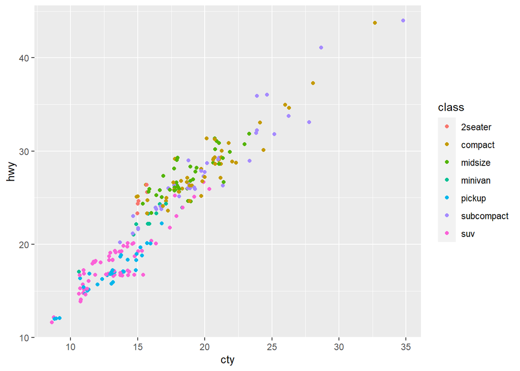

```r
ggplot(mpg, aes(cty, hwy, col = class)) +
    geom_point(position = "jitter")
```

2. 미국 지역별 인구통계 정보를 담은 ggplot2 패키지의 midwest 데이터를 이용해서 전체 인구와 아시아인 인구 간에 어떤 관계가 있는지 알아보려고 합니다. x축은 poptotal(전체 인구), y축은 popasian(아시아인 인구)으로 된 산점도를 만들어 보세요. 전체 인구는 50만 명 이하, 아시아인 인구는 1만 명 이하인 지역만 산점도에 표시되게 설정하세요.

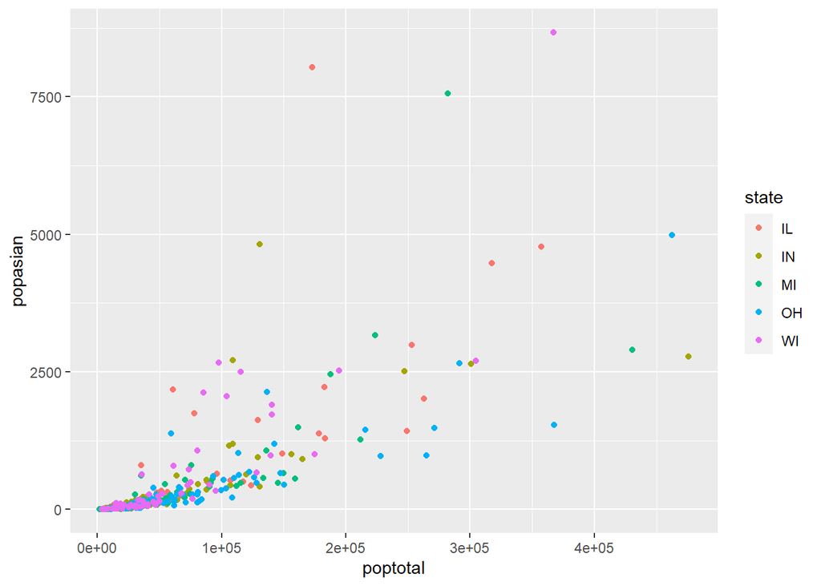

```r
midwest %>%
    filter(poptotal <= 500000, popasian <= 10000) %>%
    ggplot(aes(poptotal, popasian, col = state)) +
    geom_point(position='jitter')
```

3. 어떤 회사에서 생산한 “suv” 차종의 도시 연비가 높은지 알아보려고 합니다. “suv” 차종을 대상으로 평균 cty(도시 연비)가 가장 높은 회사 다섯 곳을 막대 그래프로 표현해 보세요. 막대는 연비가 높은 순으로 정렬하세요.

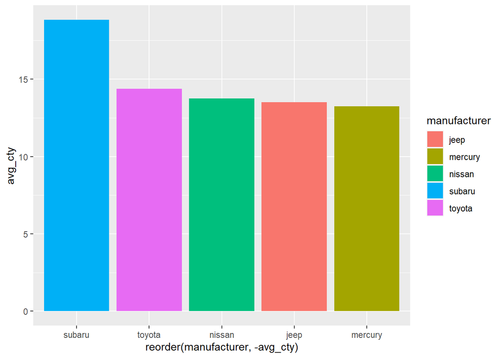

```r
mpg %>%
    filter(class == "suv") %>%
    group_by(manufacturer) %>%
    summarise(avg_cty = mean(cty)) %>%
    arrange(desc(avg_cty)) %>%
    head(5) %>%
    ggplot(aes(reorder(manufacturer, -avg_cty), avg_cty, fill = manufacturer))+
    geom_bar(stat = 'identity')
```

궁금한점: y 축 주 단위(?) 와 축 시작 값을 어떻게 조정하는가?

4. 자동차 중에서 어떤 class(자동차 종류)가 가장 많은지 알아보려고 합니다. 자동차 종류별 빈도를 표현한 막대 그래프를 만들어 보세요.

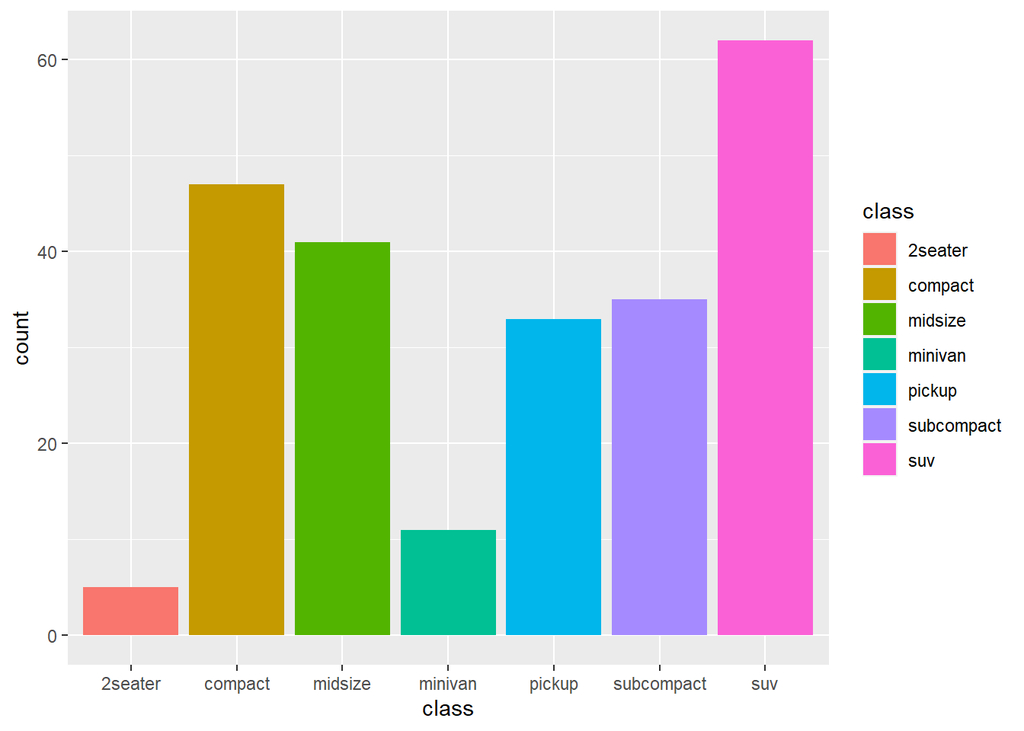

```r
ggplot(mpg, aes(class, fill = class)) +
    geom_bar()
```

궁금한점 : 빈도 막대그래프에서는 reorder y값이 없는데 어케 지정하는가?

5. economics 데이터를 이용해서 psavert(개인 저축률)가 시간에 따라서 어떻게 변해왔는지 알아보려고 합니다. 시간에 따른 개인 저축률의 변화를 나타낸 시계열 그래프를 만들어 보세요.

```r
head(economics)
```

```
## # A tibble: 6 x 6
##   date         pce    pop psavert uempmed unemploy
##   <date>     <dbl>  <dbl>   <dbl>   <dbl>    <dbl>
## 1 1967-07-01  507. 198712    12.6     4.5     2944
## 2 1967-08-01  510. 198911    12.6     4.7     2945
## 3 1967-09-01  516. 199113    11.9     4.6     2958
## 4 1967-10-01  512. 199311    12.9     4.9     3143
## 5 1967-11-01  517. 199498    12.8     4.7     3066
## 6 1967-12-01  525. 199657    11.8     4.8     3018
```

```r
library(gridExtra)
```

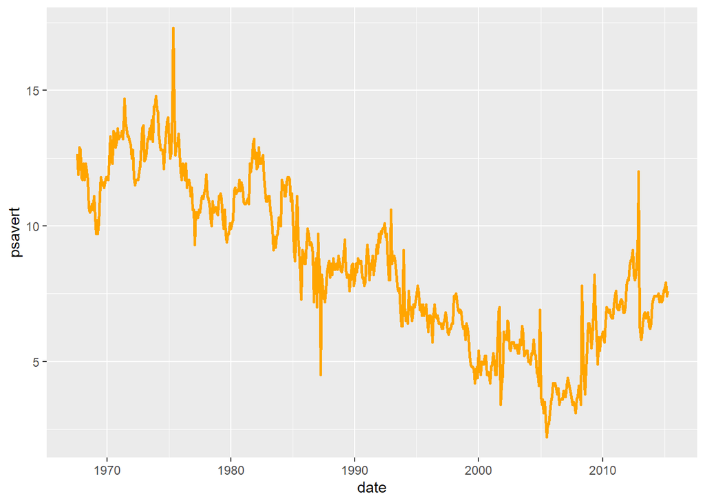

```r
ggplot(economics, aes(date, psavert)) +
    geom_line(col = "orange", size = 1)
```

6. class(자동차 종류)가 “compact”, “subcompact”, “suv”인 자동차의 cty(도시 연비)가 어떻게 다른지 비교해보려고 합니다. 세 차종의 cty를 나타낸 상자 그림을 만들어보세요.

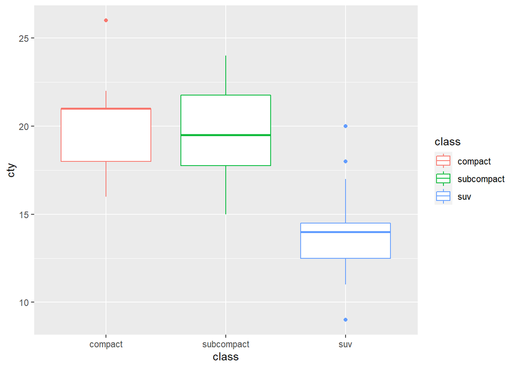

```r
mpg %>%
    filter(class == c("compact", "subcompact", "suv")) %>%
    ggplot(aes(class, cty, col = class)) +
    geom_boxplot()
```

7. Diamonds 데이터 셋을 이용하여 다음 문제를 해결하세요. 단, 컬러, 제목, x축, y축 등 그래프를 예쁘게 작성하세요.
1. cut의 돗수를 보여주는 그래프를 작성하세요.

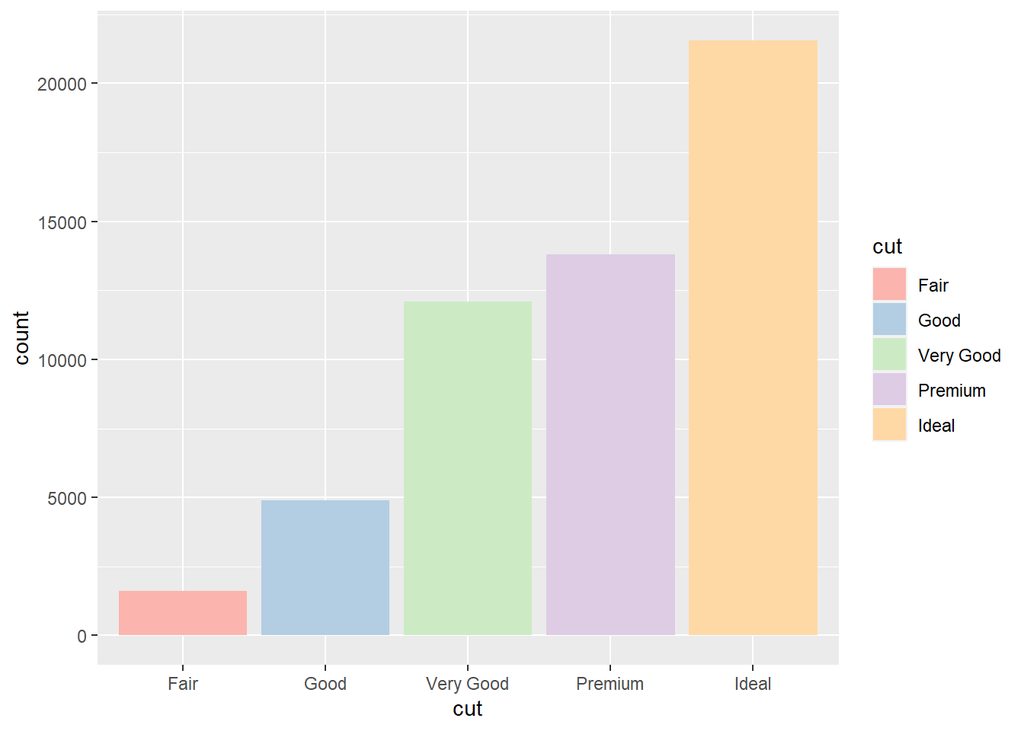

```r
ggplot(diamonds, aes(cut, fill = cut)) +
    geom_bar() +
    scale_fill_brewer(palette="Pastel1")
```

2. cut에 따른 가격의 변화를 보여주는 그래프를 작성하세요.

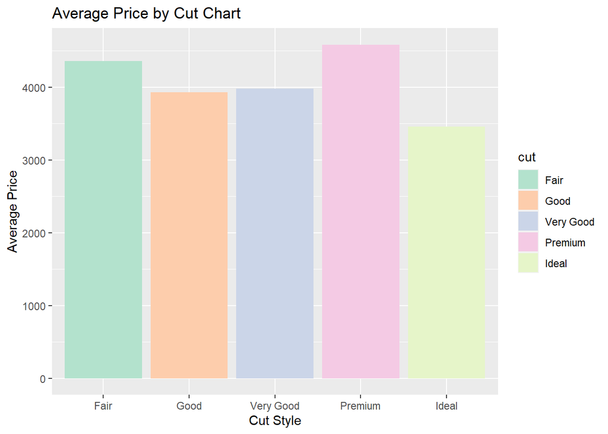

```r
diamonds %>%
    group_by(cut) %>%
    summarise(avg_price = mean(price)) %>%
    ggplot(aes(cut, avg_price, fill = cut)) +
    geom_bar(stat = "identity") +
    scale_fill_brewer(palette="Pastel2") +
    ggtitle("Average Price by Cut Chart") + xlab("Cut Style") + ylab("Average Price")
```

3. cut과 color에 따른 가격의 변화를 보여주는 그래프를 작성하세요.

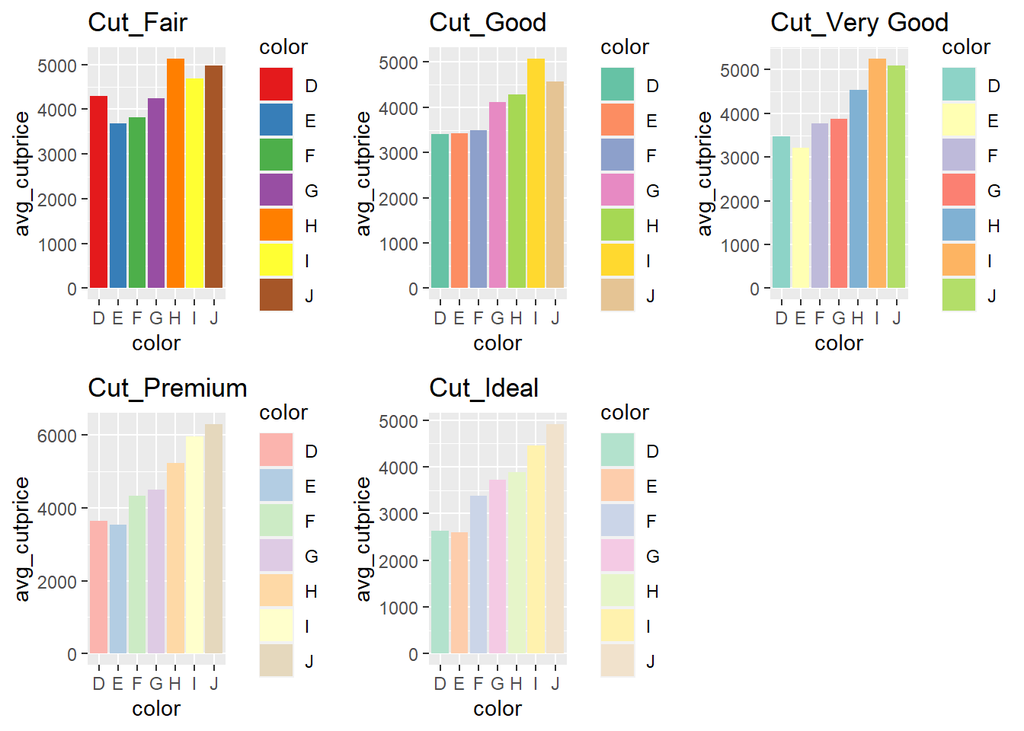

```r
library(RColorBrewer)


d1 <- diamonds %>%
    filter(cut == "Fair") %>%
    group_by(color) %>%
    summarise(avg_cutprice = mean(price)) %>%
    ggplot(aes(color, avg_cutprice, fill = color)) +
    geom_bar(stat = "identity") +
    ggtitle("Cut_Fair") + scale_fill_brewer(palette="Set1")

d2 <- diamonds %>%
    filter(cut == "Good") %>%
    group_by(color) %>%
    summarise(avg_cutprice = mean(price)) %>%
    ggplot(aes(color, avg_cutprice, fill = color)) +
    geom_bar(stat = "identity") +
    ggtitle("Cut_Good") + scale_fill_brewer(palette="Set2")

d3 <- diamonds %>%
    filter(cut == "Very Good") %>%
    group_by(color) %>%
    summarise(avg_cutprice = mean(price)) %>%
    ggplot(aes(color, avg_cutprice, fill = color)) +
    geom_bar(stat = "identity") +
    ggtitle("Cut_Very Good") + scale_fill_brewer(palette="Set3")

d4 <- diamonds %>%
    filter(cut == "Premium") %>%
    group_by(color) %>%
    summarise(avg_cutprice = mean(price)) %>%
    ggplot(aes(color, avg_cutprice, fill = color)) +
    geom_bar(stat = "identity") +
    ggtitle("Cut_Premium") + scale_fill_brewer(palette="Pastel1")

d5 <- diamonds %>%
    filter(cut == "Ideal") %>%
    group_by(color) %>%
    summarise(avg_cutprice = mean(price)) %>%
    ggplot(aes(color, avg_cutprice, fill = color)) +
    geom_bar(stat = "identity") +
    ggtitle("Cut_Ideal") + scale_fill_brewer(palette="Pastel2")

grid.arrange(d1, d2, d3, d4, d5, nrow = 2, ncol = 3)
```